# Multiple Linear Regression Project - Fırat Olçum - 20.01.2025

## 9. Değişkenlerdeki Sorunların Tespiti

🔝 İçindekilere Dön

### 9.1 Eksik Değerlerin Tespiti

🔝 İçindekilere Dön

```python
df.isnull().sum()
# Hiç bir sütunda null değer yok; Veri doldurma veya silme işlemi yapmayacağız.
```

```
MYCT     0
MMIN     0
MMAX     0
CACH     0
CHMIN    0
CHMAX    0
ERP      0
dtype: int64
```

### 9.2 Ayrık Değişkenlerdeki Uç Değerler

🔝 İçindekilere Dön

```python
df.describe()
```

|  | MYCT | MMIN | MMAX | CACH | CHMIN | CHMAX | ERP |
| --- | --- | --- | --- | --- | --- | --- | --- |
| count | 209.000 | 209.000 | 209.000 | 209.000 | 209.000 | 209.000 | 209.000 |
| mean | 203.823 | 2,867.981 | 11,796.153 | 25.206 | 4.699 | 18.268 | 99.330 |
| std | 260.263 | 3,878.743 | 11,726.564 | 40.629 | 6.816 | 25.997 | 154.757 |
| min | 17.000 | 64.000 | 64.000 | 0.000 | 0.000 | 0.000 | 15.000 |
| 25% | 50.000 | 768.000 | 4,000.000 | 0.000 | 1.000 | 5.000 | 28.000 |
| 50% | 110.000 | 2,000.000 | 8,000.000 | 8.000 | 2.000 | 8.000 | 45.000 |
| 75% | 225.000 | 4,000.000 | 16,000.000 | 32.000 | 6.000 | 24.000 | 101.000 |
| max | 1,500.000 | 32,000.000 | 64,000.000 | 256.000 | 52.000 | 176.000 | 1,238.000 |

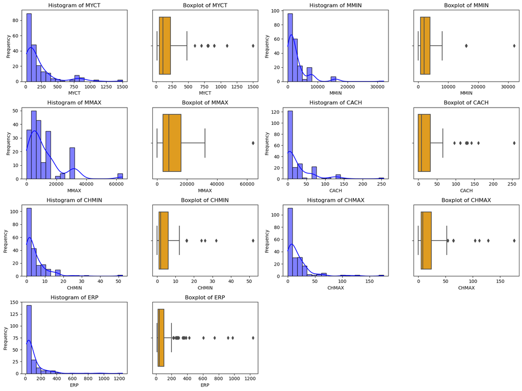

```python
numerical_cols = ['MYCT', 'MMIN', 'MMAX', 'CACH', 'CHMIN', 'CHMAX', 'ERP']

plt.figure(figsize=(16, 12))

# Her bir numerik sütun için Boxplot ve Histogram çizdirerek outlier tespiti yapmaya çalışacağım.
for i, col in enumerate(numerical_cols, 1):
    plt.subplot(4, 4, 2*i-1)
    sns.histplot(df[col], kde=True, bins=20, color='blue')
    plt.title(f'Histogram of {col}')
    plt.xlabel(col)
    plt.ylabel('Frequency')

    plt.subplot(4, 4, 2*i)
    sns.boxplot(x=df[col], color='orange')
    plt.title(f'Boxplot of {col}')
    plt.xlabel(col)

plt.tight_layout()
plt.show()

# Değerlerin aykırı değer olup olmadığını bilecek alan bilgisine sahip olmadığım için en extreme 8 adet değeri sileceğim:
    # MYCT değeri 1500' den yukarı olan veriyi sileceğim.
    # MMIN değeri 30000' den fazla olan veriyi sileceğim.
    # MMAX değeri 60000' den fazla olan veriyi sileceğim.
    # CACH değeri 250' den fazla olan veriyi sileceğim.
    # CHMIN değeri 50' den fazla olan veriyi sileceğim.
    # CHMAX değeri 150' den fazla olan veriyi sileceğim.
    # ERP değeri 1200' den fazla olan veriyi sileceğim.
```

```python
df = df[
    (df['MYCT'] <= 1500) &
    (df['MMIN'] <= 30000) &
    (df['MMAX'] <= 60000) &
    (df['CACH'] <= 250) &
    (df['CHMIN'] <= 50) &
    (df['CHMAX'] <= 150) &
    (df['ERP'] <= 1200)
]
df.shape

# 8 adet veriyi veri setinden düştük.
```

```
(201, 7)
```

## 10. Doğrusal Regresyon Modellemesi

🔝 İçindekilere Dön

### 10.1 Tahmin Edici ve Hedef Değişkenlerin Seçilmesi

🔝 İçindekilere Dön

```python
X = df.drop(columns = "ERP")
y = df[["ERP"]]
```

### 10.2 Eğitim ve Test Setlerinin Oluşturulması

🔝 İçindekilere Dön

```python
from sklearn.model_selection import train_test_split

X_train, X_test, y_train, y_test = train_test_split(X, y, test_size = 0.2, random_state = 0)
# Veri setimizde 201 satır veri var veri sayımız az bu sebeple test_size = 0.2 aldım.
```

```python
X_train.shape, y_train.shape
```

```
((160, 6), (160, 1))
```

```python
X_test.shape, y_test.shape
```

```
((41, 6), (41, 1))
```

### 10.3 Özellik Ölçeklendirmesi (Feature Scaling)

🔝 İçindekilere Dön

Veri setine baktığımızda sütunların (feature) arasında oldukça geniş bir değer aralığı olduğu görülüyor.

(Örneğin, MYCT sütunu 17 ile 1500 arasında, MMIN sütunu 64 ile 32000 arasında, ERP sütunu 15 ile 1238 arasında değerler alıyor.). Bu durum, ölçeklendirme (scaling) yapmayı zorunlu hale getiriyor.

```python
# Uç değerleri kendi değerlendirmemize göre temizlediğimiz için Standart Scaler ile scale edebiliriz.
# Verilerin ortalaması sıfıra ve standart sapması bire ayarlanacaktır.
# Aslında StandartScaler, MinMaxScaler, RobustScaler ile model performansı test edilip daha uygun olan tespit edilebilirdi...

from sklearn.preprocessing import StandardScaler

scaler = StandardScaler()

X_train = scaler.fit_transform(X_train)

X_test = scaler.transform(X_test)

# Test setine yalnızca transform işlemi uygulanır.
# Bu, eğitim setinden öğrenilen ortalama ve standart sapmayı kullanarak test setindeki verileri ölçeklendirir.
# Test seti hiçbir zaman fit edilmez.
```

### 10.4 Doğrusal Regresyon Modelinin Uygulanması

🔝 İçindekilere Dön

```python
from sklearn.linear_model import LinearRegression

lr = LinearRegression()

lr.fit(X_train, y_train)
```

```
LinearRegression()
```

## 11. Sonuçların Tahmin Edilmesi

🔝 İçindekilere Dön

```python
y_pred = lr.predict(X_test)
```

```python
lr.predict(X_test)[:5]
```

```
array([[50.78026925],
       [17.41469472],
       [35.41763086],
       [27.26488315],
       [ 2.5710314 ]])
```

## 12. Modelin Eğim ve Kesişim Terimleri

🔝 İçindekilere Dön

Eğim (Slope) parametreleri (w) ağırlıklar (Weights) veya katsayılar (Coefficients) olarak da adlandırılır. Bunlar **coef_** özniteliğinde saklanır.

Ofset veya intercept(b), **intercept_** özniteliğinde saklanır.

Bu nedenle, model eğimi **lr.coef_** ile tespit edilir ve model intercept terimi **lr.intercept_** ile tespit edilir.

```python
print("Katsayı Sayısı (Number of Coefficients):", len(lr.coef_[0]))

print("Tahmin Edilen Katsayılar (Estimated coefficients): {}".format(lr.coef_[0]))

print("Tahmin Edilen Kesişim (Estimated intercept): {}".format(lr.intercept_[0]))
```

```
Katsayı Sayısı (Number of Coefficients): 6
Tahmin Edilen Katsayılar (Estimated coefficients): [ 6.07413881 25.87648746 41.12114076 17.43958869  8.16866406  0.78436381]
Tahmin Edilen Kesişim (Estimated intercept): 75.875
```

```python
dataset = list(zip(pd.DataFrame(X_train).columns, lr.coef_[0]))

pd.DataFrame(data = dataset, columns = ['Features', 'Estimated Coefficients']).set_index('Features').reset_index()
```

|  | Features | Estimated Coefficients |
| --- | --- | --- |
| 0 | 0 | 6.074 |
| 1 | 1 | 25.876 |
| 2 | 2 | 41.121 |
| 3 | 3 | 17.440 |
| 4 | 4 | 8.169 |
| 5 | 5 | 0.784 |

## 13. Model Performansının Değerlendirilmesi

🔝 İçindekilere Dön

Regresyon problemlerinde model performansını değerlendirmenin birkaç yolu bulunmaktadır. Bunların sık kullanılanları şunlardır:

1. RMSE (Root Mean Square Error)
2. R² Puanı
3. Overfitting (Aşırı Öğrenme) ve Underfitting (Yetersiz Öğrenme)
4. Cross Validation (Çapraz Doğrulama)
5. Artık Analizi (Residual Analysis)
6. Normalite Testi

### 13.1 RMSE (Root Mean Square Error)

🔝 İçindekilere Dön

RMSE, model tarafından açıklanamayan varyansın standart sapmasını verir. Ortalama Kare Hata'nın karekökü alınarak hesaplanabilir.

RMSE, uyumun mutlak bir ölçüsüdür. Artıkların standart sapmasıyla verilen artıkların ne kadar yayıldığını verir. Veriler regresyon çizgisi etrafında ne kadar yoğunlaşırsa artıklar o kadar düşük olur ve dolayısıyla artıkların standart sapması da o kadar düşük olur. Bu, daha düşük RMSE değerleriyle sonuçlanır. Yani, daha düşük RMSE değerleri, verilerin daha iyi uyduğunu gösterir.

```python
from sklearn.metrics import mean_squared_error

mse = mean_squared_error(y_test, y_pred)
rmse = np.sqrt(mse)
print("RMSE value : {:.2f}".format(rmse))

# RMSE değerinin 17.10 olduğu bulundu.
# Bu, tahminimiz için standart sapmanın 17.10 olduğu anlamına geliyor.
```

```
RMSE value : 17.10
```

### R² Skoru

🔝 İçindekilere Dön

R² Skoru, bir regresyon modelinin performansını değerlendirmek için kullanılan bir diğer ölçüttür. Ayrıca **Belirleme Katsayısı** olarak da adlandırılır. Doğrusal regresyon modelleri için uyumun iyiliği hakkında bize bir fikir verir. Model tarafından açıklanan varyans yüzdesini gösterir.

**R² Skoru = Açıklanan Değişkenlik/Toplam Değişkenlik**

Matematiksel olarak, şunu elde ederiz : $R^2=1-\frac{SS_{res}}{SS_{tot}}$

Toplam varyans (Karelerin Toplamı), verilerin ortalamadan olan sapmalarının karesidir : $SS_{tot}=\sum_i(y_i-\bar{y})^2$

Regresyonun açıkladığı varyans (Açıklanan Kareler Toplamı) : $SS_{reg}=\sum_i(f_i-\bar{y})^2$

Artıkların kareleri toplamı (Artık Kareler Toplamı) : $SS_{res}=\sum_i(y_i-f_i)^2 = \sum_ie^2_i$

**Genel olarak, R² Sokru değeri ne kadar yüksekse, model verilere o kadar iyi uyar. Genellikle değeri 0 ile 1 arasındadır. Bu nedenle değerinin 1'e olabildiğince yakın olmasını isteriz. Modelimiz yanlışsa değeri negatif olabilir.**

```python
from sklearn.metrics import r2_score
print("R2 Score value: {:.2f}".format(r2_score(y_test, y_pred)))
```

```
R2 Score value: 0.97
```

R2 puan değeri için kıstas 0,7 kabul edilebilir. R2 puan değeri >= 0,7 ise modelin görülmemiş veriler üzerinde yeterince iyi performans gösterdiği, R2 puan değeri < 0,7 ise modelin performansının yeterince iyi olmadığı anlamına gelir.

Bizim R2 puan değerimizin 0,97 olduğu bulundu. Bu, bu modelin bağımlı değişkenimizdeki varyansın %97'sini açıkladığı anlamına gelir. Yani, R2 puan değeri, modelin verilere iyi uyum sağladığını göstermektedir.

### 13.3 Overfitting (Aşırı Öğrenme) ve Underfitting (Yetersiz Öğrenme)

🔝 İçindekilere Dön

```python
print("Training set score: {:.2f}".format(lr.score(X_train, y_train)))
```

```
Training set score: 0.97
```

```python
print("Test set score: {:.2f}".format(lr.score(X_test, y_test)))
```

```
Test set score: 0.97
```

Test ve Train setlerinin skorları birbiriyle uyumlu görünüyor.

### 13.4 Cross Validation (Çapraz Doğrulama)

🔝 İçindekilere Dön

Çapraz doğrulama, bir modeli değerlendirmede hayati bir adımdır. Modeli eğitmek için kullanılan veri miktarını en üst düzeye çıkarır.

Çapraz doğrulamada, eğitim verilerini birkaç alt gruba ayırırız. Daha sonra bunların her birini, verilerin kalan kısmına uyan modeli değerlendirmek için kullanırız.

Modelin genelleme performansının güvenilir tahminlerini elde etmemize yardımcı olur. Bu nedenle, modelin görülmemiş verilerde ne kadar iyi performans gösterdiğini anlamamıza yardımcı olur.

```python
from sklearn.model_selection import cross_val_score

cv_scores = cross_val_score(lr, X, y, cv = 5)
# 5 katlı çapraz doğrulama yapıyorum; 10 katlı da yapılabilir; hesaplama süresi uzamış olur.
```

```python
print(cv_scores.round(3))
```

```
[0.962 0.88  0.977 0.96  0.947]
```

```python
print("Average 5-Fold CV Score: {}".format(np.mean(cv_scores).round(3)))

# Modelin çapraz doğrulama sonrası ortalama puanı çok değişmiyor; puanlar arasında ufak dalgalanmalar var.
# Doğrusal regresyon modeli verilere uyuyor görünüyor.
```

```
Average 5-Fold CV Score: 0.945
```

### 13.5 Residual Analysis (Artık Analizi)

🔝 İçindekilere Dön

Doğrusal regresyon modeli verileri uygun şekilde temsil etmeyebilir. Model verilere zayıf uyum sağlayabilir. Bu nedenle, artık grafiklerini tanımlayarak ve inceleyerek modelimizi doğrulamalıyız. Bağımlı değişkenin gözlenen değeri (y) ile tahmin edilen değer (ŷi) arasındaki farka artık denir ve e ile gösterilir. Bu artıkların dağılım grafiğine artık grafiği denir.

Bir artık grafiğindeki veri noktaları yatay eksen etrafında rastgele dağılmışsa ve yaklaşık sıfır artık ortalaması varsa, doğrusal regresyon modeli veriler için uygun olabilir. Aksi takdirde doğrusal olmayan bir model daha uygun olabilir.

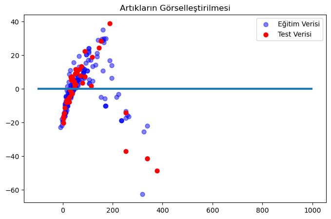

```python
plt.figure(figsize=(8,5))

# Eğitim verilerindeki artık hataların çizilmesi
plt.scatter(lr.predict(X_train), lr.predict(X_train) - y_train, c = 'b', s = 40, label = 'Eğitim Verisi', alpha = 0.5)

# Test verilerindeki artık hataların çizilmesi
plt.scatter(lr.predict(X_test), lr.predict(X_test) - y_test, c = 'r', s = 40, label = 'Test Verisi')

# Sıfır artık hatası için çizgi çizimi
plt.hlines(y = 0, xmin = -100, xmax = 1000, linewidth = 3)

plt.legend(loc = 'upper right')
plt.title("Artıkların Görselleştirilmesi")
plt.show()
```

Verilere iyi uyan bir regresyon modelinin artıkları rastgelelik (yani herhangi bir desenin olmaması) gösterecektir. Bu, regresyon modellemesinin homoskedastisite varsayımından gelir. Genellikle varsayımı doğrulamak için artıklar ve kestiriciler arasındaki saçılma grafikleri kullanılır. Saçılma grafiğindeki herhangi bir desen, bu özelliğin ihlaliyle sonuçlanır ve zayıf uyumlu bir modele işaret eder.

### 13.6 Normalite Testi (Q-Q Grafiği)

🔝 İçindekilere Dön

Bu, verilerin normalliğini kontrol etmek için görsel veya grafiksel bir testtir. Bu test, aykırı değerleri ve çarpıklığı belirlememize yardımcı olur. Test, verilerin teorik dörtlüklere göre çizilmesiyle gerçekleştirilir. Aynı veriler, normalliği doğrulamak için bir histograma da çizilir.

Normal grafikte düz çizgiden herhangi bir sapma veya histogramda çarpıklık/çoklu-modalite, verilerin normallik testini geçmediğini gösterir.

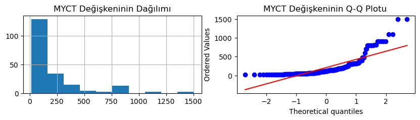

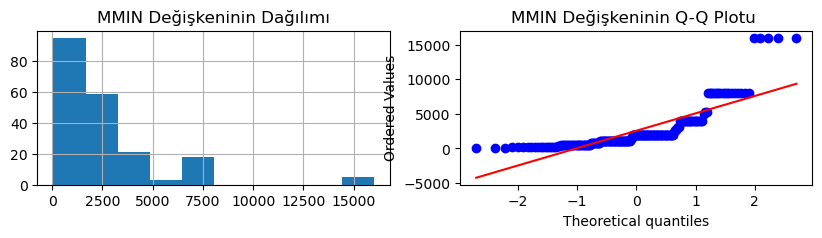

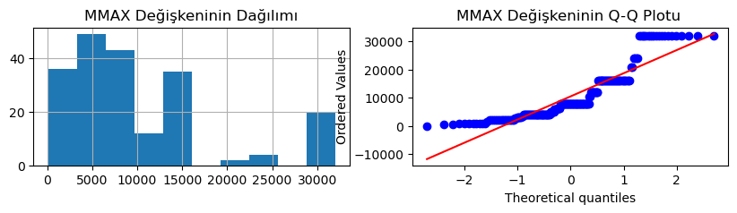

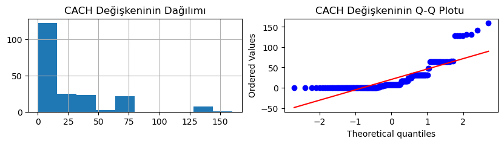

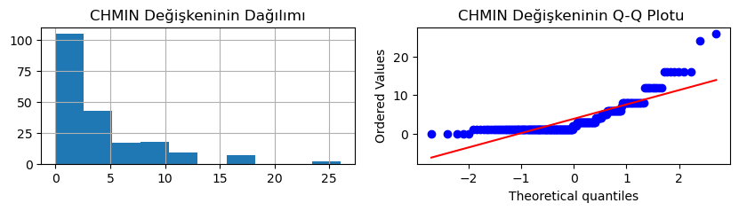

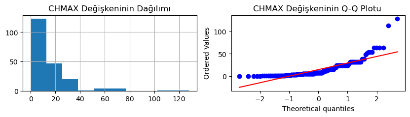

```python
import pylab
import scipy.stats as stats


for var in ['MYCT', 'MMIN', 'MMAX', 'CACH', 'CHMIN', 'CHMAX']:

    plt.figure(figsize=(10,2))

    plt.subplot(1, 2, 1)
    df[var].hist()
    plt.title(var + ' Değişkeninin Dağılımı')

    plt.subplot(1, 2, 2)
    stats.probplot(df[var], dist="norm", plot=pylab)
    plt.title(var +' Değişkeninin Q-Q Plotu ')

    plt.show()
```

Hemen hemen tüm değişkenlerde sağa çarpıklık (right skewed) ve uç değerler dikkat çekiyor. Bu durum normalite varsayımının tamamen sağlanmadığını gösteriyor.

Dağılımı normalleştirmek için **Logaritmik Dönüşüm**, **Karekök Dönüşümü** veya **Box-Cox Dönüşümü** yapabiliriz.

**Logaritmik Dönüşüm** Sağ çarpık dağılımı normalleştirme konusunda daha yardımcı olabilir.

## 14. Sonuç

🔝 İçindekilere Dön

[figure not shown]

# Multiple Linear Regression Project - Fırat Olçum - 20.01.2025